# R Notebook_Alister_Project

```r
#Importing Alberta.csv
data = read.csv("C:/Users/alist/OneDrive/Desktop/Data 606/Project/chess_df_overall.csv", header=TRUE)
head(data,3)
```

|  | rated | turns | victory_status | winner | opening_name | pace_type | W1 | B1 | W_First5 | B_First5 | Rating_WB |
| --- | --- | --- | --- | --- | --- | --- | --- | --- | --- | --- | --- |
| 1 | FALSE | 13 | OUTOFTIME | WHITE | SLAV DEFENSE: EXCHANGE VARIATION | STANDARD | d4 | d5 | d4_c4_cxd5_dxe6_Nf3 | d5_c6_e6_fxe6_Bb4+ | 1.2594458 |
| 2 | TRUE | 16 | RESIGN | BLACK | NIMZOWITSCH DEFENSE: KENNEDY VARIATION | BLITZ | d4 | Nc6 | d4_e4_f4_dxe5_fxe5 | Nc6_e5_f6_fxe5_Nxe5 | 1.0483743 |
| 3 | TRUE | 61 | MATE | WHITE | KING'S PAWN GAME: LEONARDIS VARIATION | BLITZ | e4 | e5 | e4_d3_Be3_Be2_Nd2 | e5_d6_c6_b5_a5 | 0.9973333 |

```r
df2<-data[!(data$winner=="DRAW"),]
df2
```

|  | rated | turns | victory_status | winner | opening_name | pace_type | W1 | B1 | W_First5 | B_First5 | Rating_WB |
| --- | --- | --- | --- | --- | --- | --- | --- | --- | --- | --- | --- |
| 1 | FALSE | 13 | OUTOFTIME | WHITE | SLAV DEFENSE: EXCHANGE VARIATION | STANDARD | d4 | d5 | d4_c4_cxd5_dxe6_Nf3 | d5_c6_e6_fxe6_Bb4+ | 1.2594458 |
| 2 | TRUE | 16 | RESIGN | BLACK | NIMZOWITSCH DEFENSE: KENNEDY VARIATION | BLITZ | d4 | Nc6 | d4_e4_f4_dxe5_fxe5 | Nc6_e5_f6_fxe5_Nxe5 | 1.0483743 |
| 3 | TRUE | 61 | MATE | WHITE | KING'S PAWN GAME: LEONARDIS VARIATION | BLITZ | e4 | e5 | e4_d3_Be3_Be2_Nd2 | e5_d6_c6_b5_a5 | 0.9973333 |
| 4 | TRUE | 61 | MATE | WHITE | QUEEN'S PAWN GAME: ZUKERTORT VARIATION | STANDARD | d4 | d5 | d4_Nf3_Nc3_Bf4_e3 | d5_Bf5_Nf6_Ng4_Nc6 | 0.9896836 |
| 5 | TRUE | 95 | MATE | WHITE | PHILIDOR DEFENSE | STANDARD | e4 | e5 | e4_Nf3_d4_d5_a3 | e5_d6_Nc6_Nb4_Na6 | 1.0367597 |
| 7 | TRUE | 33 | RESIGN | WHITE | BLACKMAR-DIEMER GAMBIT: PIETROWSKY DEFENSE | BLITZ | d4 | d5 | d4_e4_Nc3_f3_Nxf3 | d5_dxe4_Nf6_exf3_Nc6 | 1.0681658 |
| 8 | FALSE | 9 | RESIGN | BLACK | NIMZOWITSCH DEFENSE: KENNEDY VARIATION \| LINKSSPRINGER VARIATION | STANDARD | e4 | Nc6 | e4_d4_d5_c3_b4 | Nc6_e5_Nce7_Ng6_ | 0.6703036 |
| 9 | TRUE | 66 | RESIGN | BLACK | ITALIAN GAME: SCHILLING-KOSTIC GAMBIT | STANDARD | e4 | e5 | e4_Bc4_Nf3_d3_Qxf3 | e5_Nc6_Nd4_Nxf3+_Nf6 | 1.0337644 |
| 10 | TRUE | 119 | MATE | WHITE | SCANDINAVIAN DEFENSE: MIESES-KOTROC VARIATION | BLITZ | e4 | d5 | e4_exd5_Nc3_Be2_d4 | d5_Qxd5_Qe5+_Na6_Qf5 | 1.1422663 |
| 11 | FALSE | 39 | MATE | WHITE | VAN'T KRUIJS OPENING | STANDARD | e3 | e6 | e3_d4_Bd3_Nf3_Nc3 | e6_d6_c6_Be7_Nf6 | 1.0856918 |

[output cut: 990 more lines]

```r
unique(df2$winner)
```

```
[1] "WHITE" "BLACK"
```

```r
#write.csv(df2 , "C:/Users/alist/OneDrive/Desktop/Data 606/Project/chess_df_draw_dropped.csv", row.names=TRUE)
```

```r
#Q -Q plot Normality test
df2.white<-subset(df2,winner =="WHITE")
df2.black<-subset(df2,winner =="BLACK")
```

```r
variable_1<-c("turns","Rating_WB")
par(mfrow = c(2,1))

for(i in variable_1) {
  qqnorm(df2.white[[i]]);qqline(df2.white[[i]])}
```

[output not shown]

```r
shapiro.test(df2.white$turns[0:5000])
shapiro.test(df2.white$Rating_WB[0:5000])
```

[output not shown]

```r
library(nortest)
ad.test(df2.white$turns)
ad.test(df2.white$Rating_WB)
```

[output not shown]

```r
par(mfrow = c(2,1))
for(i in variable_1) {
  qqnorm(df2.black[[i]]);qqline(df2.black[[i]])}
```

[output not shown]

```r
shapiro.test(df2.black$turns[0:5000])
shapiro.test(df2.black$Rating_WB[0:5000])
```

[output not shown]

```r
library(nortest)
ad.test(df2.black$turns)
ad.test(df2.black$Rating_WB)
```

[output not shown]

> Variance test

```r
df2.sub = subset(df2,select = c(turns,Rating_WB))
df2.sub
```

|  | turns | Rating_WB |
| --- | --- | --- |
| 1 | 13 | 1.2594458 |
| 2 | 16 | 1.0483743 |
| 3 | 61 | 0.9973333 |
| 4 | 61 | 0.9896836 |
| 5 | 95 | 1.0367597 |
| 7 | 33 | 1.0681658 |
| 8 | 9 | 0.6703036 |
| 9 | 66 | 1.0337644 |
| 10 | 119 | 1.1422663 |
| 11 | 39 | 1.0856918 |

[output cut: 990 more lines]

```r
library(lmtest)
bptest(df2.sub$Rating_WB)
```

```
Error in formula$x : $ operator is invalid for atomic vectors
```

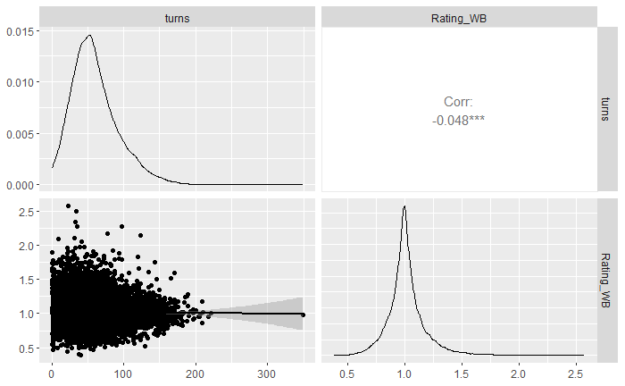

```r
library(ggplot2)
library(GGally)
ggpairs(df2.sub,lower = list(continuous = "smooth_loess",combo ="facethist",discrete = "facetbar",na ="na"))
```

> Pending to check independence

# Q2

> Reading the file for second question:

```r
#File for second question
data_Q2 = read.csv("C:/Users/alist/OneDrive/Desktop/Data 606/Project/data-606-project/chess_strat_Q2.csv", header=TRUE)
head(data_Q2,3)
```

|  | rated | turns | victory_status | winner | pace_type | W1 | B1 | Rating_WB | opening_strategy | op_name | rating_bins |
| --- | --- | --- | --- | --- | --- | --- | --- | --- | --- | --- | --- |
| 1 | FALSE | 13 | OUTOFTIME | WHITE | STANDARD | d4 | d5 | 1.2594458 | DEFENSE | SLAV DEFENSE | Equal |
| 2 | TRUE | 16 | RESIGN | BLACK | BLITZ | d4 | Nc6 | 1.0483743 | DEFENSE | NIMZOWITSCH DEFENSE | Equal |
| 3 | TRUE | 61 | MATE | WHITE | BLITZ | e4 | e5 | 0.9973333 | NO_DEFENSE | KING'S PAWN GAME | Equal |

# Q2 Normality plot

```r
unique(data_Q2$victory_status)
```

```
[1] "OUTOFTIME" "RESIGN"    "MATE"
```

```r
#Q -Q plot Normality test
Q2.outoftime<-subset(data_Q2,victory_status =="OUTOFTIME")
Q2.resign<-subset(data_Q2,victory_status =="RESIGN")
Q2.mate<-subset(data_Q2,victory_status =="MATE")
```

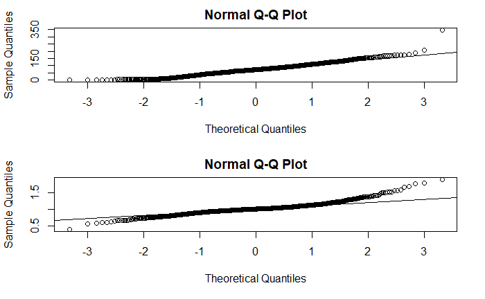

```r
variable_2<-c("turns","Rating_WB")
par(mfrow = c(2,1))

for(i in variable_2) {
  qqnorm(Q2.outoftime[[i]]);qqline(Q2.outoftime[[i]])}
```

```r
shapiro.test(Q2.outoftime$turns[0:5000])
```

```
    Shapiro-Wilk normality test

data:  Q2.outoftime$turns[0:5000]
W = 0.97399, p-value = 3.495e-13
```

```r
shapiro.test(Q2.outoftime$Rating_WB[0:5000])
```

```
    Shapiro-Wilk normality test

data:  Q2.outoftime$Rating_WB[0:5000]
W = 0.93471, p-value < 2.2e-16
```

```r
library(nortest)
ad.test(Q2.outoftime$turns)
```

```
    Anderson-Darling normality test

data:  Q2.outoftime$turns
A = 2.306, p-value = 7.646e-06
```

```r
ad.test(Q2.outoftime$Rating_WB)
```

```
    Anderson-Darling normality test

data:  Q2.outoftime$Rating_WB
A = 18.741, p-value < 2.2e-16
```

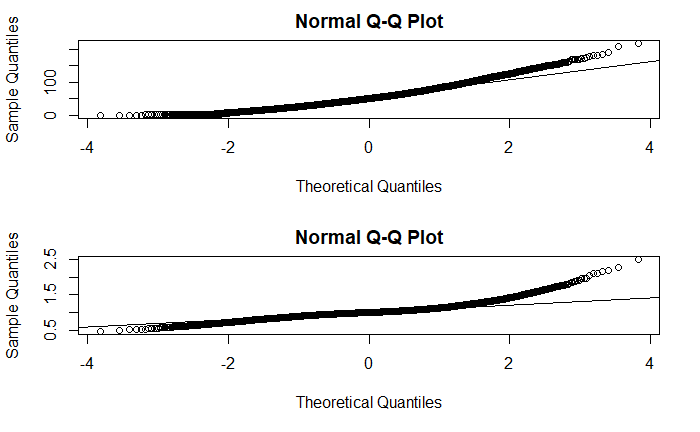

```r
par(mfrow = c(2,1))
for(i in variable_2) {
  qqnorm(Q2.resign[[i]]);qqline(Q2.resign[[i]])}
```

```r
shapiro.test(Q2.resign$turns[0:5000])
```

```
    Shapiro-Wilk normality test

data:  Q2.resign$turns[0:5000]
W = 0.96295, p-value < 2.2e-16
```

```r
shapiro.test(Q2.resign$Rating_WB[0:5000])
```

```
    Shapiro-Wilk normality test

data:  Q2.resign$Rating_WB[0:5000]
W = 0.9888, p-value < 2.2e-16
```

```r
library(nortest)
ad.test(Q2.resign$turns)
```

```
    Anderson-Darling normality test

data:  Q2.resign$turns
A = 65.055, p-value < 2.2e-16
```

```r
ad.test(Q2.resign$Rating_WB)
```

```
    Anderson-Darling normality test

data:  Q2.resign$Rating_WB
A = 158.96, p-value < 2.2e-16
```

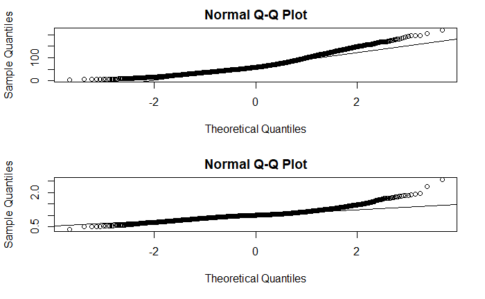

```r
par(mfrow = c(2,1))
for(i in variable_2) {
  qqnorm(Q2.mate[[i]]);qqline(Q2.mate[[i]])}
```

```r
shapiro.test(Q2.mate$turns[0:5000])
```

```
    Shapiro-Wilk normality test

data:  Q2.mate$turns[0:5000]
W = 0.945, p-value < 2.2e-16
```

```r
shapiro.test(Q2.mate$Rating_WB[0:5000])
```

```
    Shapiro-Wilk normality test

data:  Q2.mate$Rating_WB[0:5000]
W = 0.93191, p-value < 2.2e-16
```

```r
library(nortest)
ad.test(Q2.mate$turns)
```

```
    Anderson-Darling normality test

data:  Q2.mate$turns
A = 65.854, p-value < 2.2e-16
```

```r
ad.test(Q2.mate$Rating_WB)
```

```
    Anderson-Darling normality test

data:  Q2.mate$Rating_WB
A = 69.783, p-value < 2.2e-16
```

> Variance Test for Q2

```r
Q2.sub = subset(data_Q2,select = c(turns,Rating_WB))
Q2.sub
```

|  | turns | Rating_WB |
| --- | --- | --- |
| 1 | 13 | 1.2594458 |
| 2 | 16 | 1.0483743 |
| 3 | 61 | 0.9973333 |
| 4 | 95 | 1.0367597 |
| 5 | 33 | 1.0681658 |
| 6 | 66 | 1.0337644 |
| 7 | 119 | 1.1422663 |
| 8 | 39 | 1.0856918 |
| 9 | 38 | 0.7396893 |
| 10 | 60 | 0.7133264 |

[output cut: 990 more lines]

> Checking the assumption of equal variance

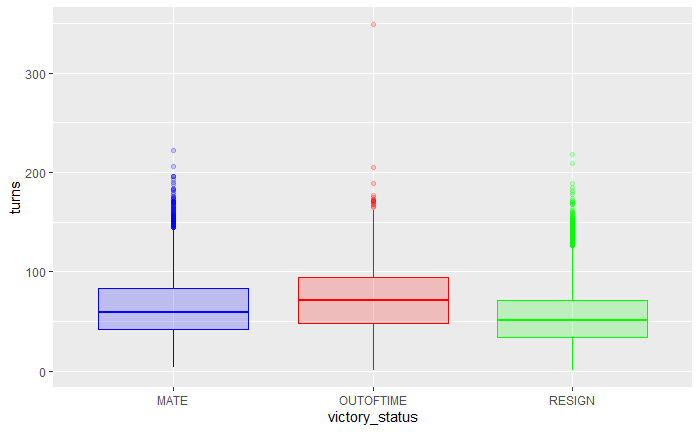

```r
ggplot(data_Q2,
                        aes_string(x = "victory_status",
                                   y = "turns",
                                   col = "victory_status",
                                   fill = "victory_status")) +
    geom_boxplot(alpha = 0.2) +
    theme(legend.position = "none") +
    scale_color_manual(values = c("blue", "red","green")) +
    scale_fill_manual(values = c("blue", "red","green"))
```

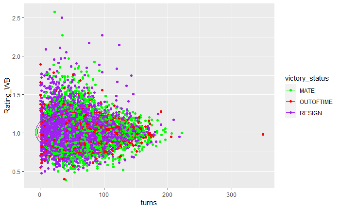

H0: Covariance matrices of the outcome variable are equal across all groups Ha: COvariance matrices of the outcome variable are different for at least one group

```r
boxm <- heplots::boxM(data_Q2[, c(2,8)], data_Q2$victory_status)
boxm
```

```
    Box's M-test for Homogeneity of Covariance Matrices

data:  data_Q2[, c(2, 8)]
Chi-Sq (approx.) = 264.95, df = 6, p-value < 2.2e-16
```

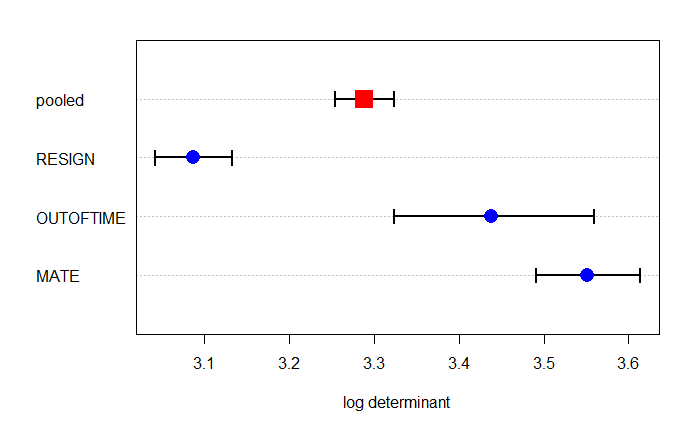

```r
plot(boxm)
```

> The values are not homogenous

```r
#As an additional check, we can perform a Levene test to check for equal variances.

car::leveneTest(turns ~ victory_status, data_Q2)
```

```
Levene's Test for Homogeneity of Variance (center = median)
         Df F value    Pr(>F)
group     2  55.234 < 2.2e-16 ***
      12753
---
Signif. codes:  0 ‘***’ 0.001 ‘**’ 0.01 ‘*’ 0.05 ‘.’ 0.1 ‘ ’ 1
```

```r
car::leveneTest(Rating_WB ~ victory_status, data_Q2)
```

```
Levene's Test for Homogeneity of Variance (center = median)
         Df F value    Pr(>F)
group     2  26.129 4.738e-12 ***
      12753
---
Signif. codes:  0 ‘***’ 0.001 ‘**’ 0.01 ‘*’ 0.05 ‘.’ 0.1 ‘ ’ 1
```

```r
library(ggplot2)
library(GGally)
ggpairs(Q2.sub,lower = list(continuous = "smooth_loess",combo ="facethist",discrete = "facetbar",na ="na"))
```

[output not shown]

> Multinomial Regression for Q2

> Checking the levels in the response variable

```r
any(is.na(data_Q2$victory_status))
```

```
[1] FALSE
```

```r
data_Q2$vicfact<-factor(data_Q2$victory_status)
```

```r
unique(data_Q2$vicfact)
```

```
[1] OUTOFTIME RESIGN    MATE
Levels: MATE OUTOFTIME RESIGN
```

```r
library(tidyverse)
library(nnet)
```

```r
data_Q2
```

| rated | turns | victory_status | winner | pace_type | W1 | B1 | Rating_WB | opening_strategy | op_name | rating_bins | vicfact |
| --- | --- | --- | --- | --- | --- | --- | --- | --- | --- | --- | --- |
| FALSE | 13 | OUTOFTIME | WHITE | STANDARD | d4 | d5 | 1.2594458 | DEFENSE | SLAV DEFENSE | Equal | OUTOFTIME |
| TRUE | 16 | RESIGN | BLACK | BLITZ | d4 | Nc6 | 1.0483743 | DEFENSE | NIMZOWITSCH DEFENSE | Equal | RESIGN |
| TRUE | 61 | MATE | WHITE | BLITZ | e4 | e5 | 0.9973333 | NO_DEFENSE | KING'S PAWN GAME | Equal | MATE |
| TRUE | 95 | MATE | WHITE | STANDARD | e4 | e5 | 1.0367597 | DEFENSE | PHILIDOR DEFENSE | Equal | MATE |
| TRUE | 33 | RESIGN | WHITE | BLITZ | d4 | d5 | 1.0681658 | DEFENSE | OTHER | Equal | RESIGN |
| TRUE | 66 | RESIGN | BLACK | STANDARD | e4 | e5 | 1.0337644 | NO_DEFENSE | ITALIAN GAME | Equal | RESIGN |
| TRUE | 119 | MATE | WHITE | BLITZ | e4 | d5 | 1.1422663 | DEFENSE | SCANDINAVIAN DEFENSE | Equal | MATE |
| FALSE | 39 | MATE | WHITE | STANDARD | e3 | e6 | 1.0856918 | NO_DEFENSE | VAN'T KRUIJS OPENING | Equal | MATE |
| FALSE | 38 | RESIGN | BLACK | STANDARD | e4 | e6 | 0.7396893 | DEFENSE | FRENCH DEFENSE | Equal | RESIGN |
| FALSE | 60 | RESIGN | BLACK | BLITZ | e4 | e6 | 0.7133264 | DEFENSE | FRENCH DEFENSE | Equal | RESIGN |

[output cut: 990 more lines]

```r
library(VGAM)
n.model<-vglm(vicfact~rated+turns+pace_type+Rating_WB+opening_strategy,family=multinomial(),data = data_Q2)
```

```r
summary(n.model)
```

```
Call:
vglm(formula = vicfact ~ rated + turns + pace_type + Rating_WB +
    opening_strategy, family = multinomial(), data = data_Q2)

Coefficients:
                              Estimate Std. Error z value Pr(>|z|)
(Intercept):1                -1.488554   0.142412 -10.452  < 2e-16 ***
(Intercept):2                -2.629234   0.241609 -10.882  < 2e-16 ***
ratedTRUE:1                  -0.001223   0.052796  -0.023   0.9815
ratedTRUE:2                  -0.171521   0.087100  -1.969   0.0489 *
turns:1                       0.011095   0.000626  17.726  < 2e-16 ***
turns:2                       0.016269   0.000952  17.089  < 2e-16 ***
pace_typeBULLET:1             0.331749   0.241058   1.376   0.1688
pace_typeBULLET:2             0.465041   0.357289   1.302   0.1931
pace_typeSTANDARD:1          -0.031502   0.043328  -0.727   0.4672
pace_typeSTANDARD:2          -0.633045   0.082580  -7.666 1.78e-14 ***
Rating_WB:1                   0.127289   0.120221   1.059   0.2897
Rating_WB:2                  -0.049656   0.207824  -0.239   0.8112
opening_strategyNO_DEFENSE:1  0.232746   0.039593   5.879 4.14e-09 ***
opening_strategyNO_DEFENSE:2  0.069240   0.066279   1.045   0.2962
---
Signif. codes:  0 ‘***’ 0.001 ‘**’ 0.01 ‘*’ 0.05 ‘.’ 0.1 ‘ ’ 1

Names of linear predictors: log(mu[,1]/mu[,3]), log(mu[,2]/mu[,3])

Residual deviance: 22077.68 on 25498 degrees of freedom

Log-likelihood: -11038.84 on 25498 degrees of freedom

Number of Fisher scoring iterations: 5

Warning: Hauck-Donner effect detected in the following estimate(s):
'(Intercept):2'


Reference group is level  3  of the response
```

```r
n2.model<-vglm(vicfact~turns+pace_type+opening_strategy,family=multinomial,data = data_Q2)
```

```r
summary(n2.model)
```

```
Call:
vglm(formula = vicfact ~ turns + pace_type + opening_strategy,
    family = multinomial, data = data_Q2)

Coefficients:
                               Estimate Std. Error z value Pr(>|z|)
(Intercept):1                -1.3574285  0.0490818 -27.656  < 2e-16 ***
(Intercept):2                -2.8183792  0.0808151 -34.874  < 2e-16 ***
turns:1                       0.0110569  0.0006230  17.749  < 2e-16 ***
turns:2                       0.0161311  0.0009485  17.007  < 2e-16 ***
pace_typeBULLET:1             0.3262185  0.2409017   1.354    0.176
pace_typeBULLET:2             0.4792689  0.3568637   1.343    0.179
pace_typeSTANDARD:1          -0.0312263  0.0430755  -0.725    0.469
pace_typeSTANDARD:2          -0.6176830  0.0821615  -7.518 5.57e-14 ***
opening_strategyNO_DEFENSE:1  0.2319306  0.0395607   5.863 4.56e-09 ***
opening_strategyNO_DEFENSE:2  0.0739555  0.0662093   1.117    0.264
---
Signif. codes:  0 ‘***’ 0.001 ‘**’ 0.01 ‘*’ 0.05 ‘.’ 0.1 ‘ ’ 1

Names of linear predictors: log(mu[,1]/mu[,3]), log(mu[,2]/mu[,3])

Residual deviance: 22082.89 on 25502 degrees of freedom

Log-likelihood: -11041.45 on 25502 degrees of freedom

Number of Fisher scoring iterations: 5

Warning: Hauck-Donner effect detected in the following estimate(s):
'(Intercept):2'


Reference group is level  3  of the response
```

> Plotting the model coefficients with the training set

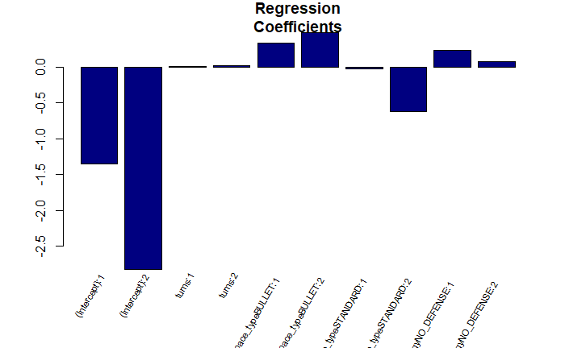

```r
cf.n2.model<-coefficients(n2.model)
plot.n2.model<-barplot(cf.n2.model, col="navy blue", xaxt='n', main="Regression
Coefficients")
lablist.n2.model <- names(cf.n2.model)
text(plot.n2.model, par("usr")[3], labels = lablist.n2.model, srt = 60, adj =
c(1.1,1.1), xpd = TRUE, cex=0.7)
```

# Goodness of fit

The hypotheses for this test are: H0: there is no significant difference between the observed and the expected value. Ha: there is a significant difference between the observed and the expected value.

```r
1-pchisq(sum(resid(n2.model,
type="pearson")^2),df.residual(n2.model))
```

```
[1] 0.1121193
```

> The P-value is large and we fail to reject the null hypothesis and there is no difference between the observed and expected value. Hence our model provides a good fit.

# Check accuracy on train

```r
prob.fit.n2.model<-predict(n2.model, newdata=data_Q2,type="response") # return the probability of being in one of category of victory  status
```

```r
library(matrixStats)
colnames<-c("MATE","OUTOFTIME","RESIGN")
fitted_train<-apply(prob.fit.n2.model, 1, function(x) {colnames[which.max(x)]}) # turn probabilities into actual categories, pick the max of each row and return the column name associated with it
```

```r
x1<-data.frame(fitted_train)
head(x1)
```

|  | fitted_train |
| --- | --- |
| 1 | RESIGN |
| 2 | RESIGN |
| 3 | RESIGN |
| 4 | RESIGN |
| 5 | RESIGN |
| 6 | RESIGN |

```r
head(data.frame(Observed_value = data_Q2$vicfact, Fitted_value =
fitted_train))
```

|  | Observed_value | Fitted_value |
| --- | --- | --- |
| 1 | OUTOFTIME | RESIGN |
| 2 | RESIGN | RESIGN |
| 3 | MATE | RESIGN |
| 4 | MATE | RESIGN |
| 5 | RESIGN | RESIGN |
| 6 | RESIGN | RESIGN |

```r
misclass_train <- mean(fitted_train != data_Q2$vicfact)
print(paste('Accuracy %',round((1-misclass_train)*100 ,2)))
```

```
[1] "Accuracy % 59.6"
```

# Cross validation for Multinomial model

```r
library(caret)
set.seed(5)
folds<-createFolds(factor(data_Q2$vicfact), k=10)
```

> Writing functions to calculate the cross validation error

```r
#Multinomial regression
mcr.mnr<-function(idx){
  Train<-data_Q2[-idx,]
  Test<-data_Q2[idx,]
  fitmnr<-vglm(vicfact~turns+pace_type+opening_strategy,family=multinomial,data = Train)
  pred_victor<-predict(fitmnr,Test,type = "response")
  predictmnr2 <- apply(pred_victor, 1, function(x) {colnames[which.max(x)]})
  return(mean(predictmnr2 != Test$vicfact))
}
```

```r
mnr = lapply(folds,mcr.mnr)
mean(as.numeric(mnr))
```

```
[1] 0.4047514
```